# Recommendation with Side Information

From cold start to side-aware factors and two-tower networks

Ben Dai

CUHK · Department of Statistics and Data Science

## The ID-only limit

$$\widehat r_{ui}=p_u^\top q_i\quad\text{requires learned rows }p_u\text{ and }q_i$$

WARM START**Known user and item**

Both embeddings were learned from training interactions.

COLD START**New user or item**

No fitted row exists for that ID. The dot product alone has nothing to look up.

We need information that can be available **before** a new entity has ratings.

## Side information describes the entity

USER**profile features**

For example, age group, stated interests, or a self-description.

ITEM**content features**

For example, film genre, release year, or a text description.

CONTEXT**event features**

For example, time or device, if known at prediction time.

A useful cold-start feature must exist when the recommendation is made. A rating-derived statistic may not.

## The prediction row is now richer

user ID $u$  
optional history

*+*

user features $x_u$

*+*

item ID $i$

*+*

item features $z_i$

*→*

rating $r_{ui}$

TRAIN**inputs and known rating**

Learn how IDs and features relate to ratings.

PREDICT**inputs, unknown rating**

Apply the same feature transformations to a new pair.

## Three ways to use the extra information

FEATURES ONLY**$f(x_u,z_i)$**

Can handle new IDs, but may miss individual preferences.

ADD TO MF**$p_u^\top q_i+f(x_u,z_i)$**

Keep personalized ID factors and add a feature contribution.

SIDE-AWARE FACTORS**$p(u,x_u)^\top q(i,z_i)$**

Build each factor vector from ID and features together.

The third approach makes the interaction depend on the features on **both** sides.

## Numeric and categorical features enter differently

NUMERIC**age, release year**

Pass a numerical value through a suitable transformation. Learn any scaling from training data only.

CATEGORICAL**genre, occupation**

Map each category to an integer lookup position, then learn an embedding for it.

$$\text{genre = comedy}\;\longrightarrow\;j\;\longrightarrow\;e_j\in\mathbb R^K$$

An ID is itself a categorical feature. The same embedding idea can represent other categories.

## A feature embedding is another learned table

Suppose a film has one genre field with three possible values.

| category | encoded index | learned vector |
| --- | --- | --- |
| action | 0 | $e_0$ |
| comedy | 1 | $e_1$ |
| drama | 2 | $e_2$ |

The indices only select rows. The embedding coordinates are learned from the rating objective.

## A linear side-aware factor model

$$p(u,x_u)=p_u+A x_u+e_{c(u)},\qquad q(i,z_i)=q_i+B z_i+e_{g(i)}$$

USER VECTOR**ID + numeric + category**

$p_u$ is personalized; $A x_u$ and $e_{c(u)}$ bring in user features.

ITEM VECTOR**ID + numeric + category**

$q_i$ is item-specific; $B z_i$ and $e_{g(i)}$ bring in item features.

$$\widehat r_{ui}=p(u,x_u)^\top q(i,z_i)$$

## Four questions for the side-aware model

1 · MODEL**factor vectors from IDs + features**

Predict with $p(u,x_u)^\top q(i,z_i)$.

2 · HYPERPARAMETERS**$K$ and regularization**

Choose factor width and shrinkage before fitting.

3 · CRITERION**rating error + penalty**

Minimize errors on training pairs, with a complexity control.

4 · LEARNED**embeddings + maps**

ID/category tables and feature maps $A,B$.

## The linear architecture as a network

user ID + category + numeric features

*→*

ID/category lookups + $A x_u$

*→*

user factor  
$p(u,x_u)$

item ID + genre + numeric features

*→*

ID/category lookups + $B z_i$

*→*

item factor  
$q(i,z_i)$

$$\widehat r_{ui}=p(u,x_u)^\top q(i,z_i)$$

Numeric transformations and categorical lookups build the two factor vectors; their inner product predicts the rating.

## From linear maps to two towers

USER TOWER**$h_u=F_u(u,x_u)$**

Combine user ID, numeric features, and category embeddings through a network.

ITEM TOWER**$h_i=F_i(i,z_i)$**

Do the same for item ID and content features.

$$\widehat r_{ui}=\rho(h_u,h_i)$$

Each tower can learn nonlinear **within-side** feature interactions before the two representations meet.

## Follow the two-tower computation

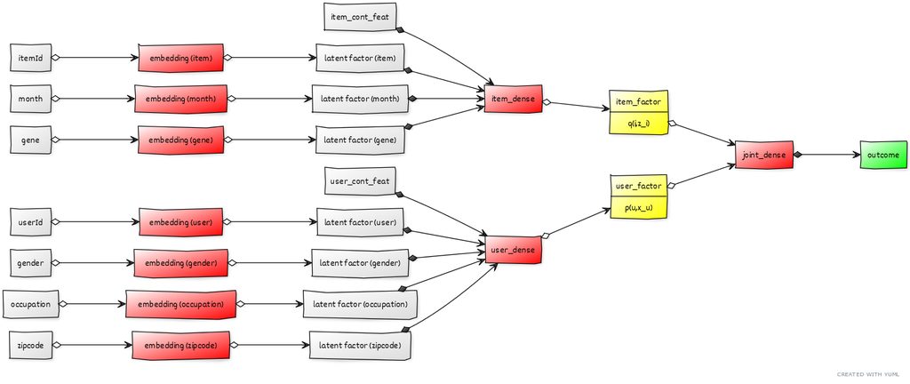

The final interaction can be a dot product or a learned joint network. That choice changes the model family.

## What happens to a new user?

new user ID  
**no fitted ID row**

*+*

available profile  
**$x_{\rm new}$**

*→*

user tower  
**$h_{\rm new}$**

*→*

item tower  
**$h_i$**

*→*

prediction

For cold start, the model must define how to handle the missing ID embedding. Side features can then supply a representation.

## Guard the validation boundary

SAFE FEATURE**known before rating**

A film’s genre or an already-available user profile can be used directly.

RATING-DERIVED FEATURE**mean, count, quantile**

Compute from the fitting fold only. A held-out rating must never help create its own input feature.

For each CV fold: split first → learn encodings and summaries on fitting rows → transform held-out rows → score.

## Beyond tabular features

TEXT**queries and reviews**

Convert content into numerical representations.

IMAGES**item photos**

Use visual encoders to build item features.

BEHAVIOR**interaction sequence**

Summarize recent actions to represent current interests.

Whatever the modality, ask whether its information is available when the prediction is made.

## Close the loop

ID-only MF  
**personalization**

*→*

side-aware factors  
**metadata**

*→*

two towers  
**nonlinear representations**

Side information helps with cold start, but only a carefully specified fallback and a leakage-safe validation scheme make that benefit measurable.